# WABS Method to estimate prob of collision

Bruce Hartman

February 1, 2019; updated March 31, 2025

Abstract

We estimate the probability of a train colliding with a pedestrian using SMART data obtained from the FRA’s WABS databases. We use logistic regression and produce estimates for SMART crossings.

# 1 Introduction

In this essay we address the problem of estimating, from data provided by the FRA in the WABS databases, the probability of a collision at specific rail crossings in a year. WABS itself makes some estimates, but does not document the method used for making them. We are not trying to replicate the WABS results, but instead develop here an independent method based on logistic regression.

Logistic regression is a way of estimating the probability of an event, such as an accident or collision, happening. The response variable is a binary variable indicating whether an accident occurs or not. Predictor variables are taken from the data fields provided by WABS. Logistic regression allows either continuous or discrete values of predictors, including factors (which might be character data in the data file). It uses a version of regression which chooses coefficients based on maximum likelihood, instead of least square error, which is used in ordinary regression. In addition, the response variable does not follow a normal distribution, but a binomial one, so that ordinary least squares methods of analysis of results are inappropriate.

# 2 Data

WABS Accident data is contained in pdf documents downloadable from their website. The files are not downloadable in any other format. We extracted the data from the pdf and edited the files, using Notepad+, to get columns and field names aligned properly, and then used the RStudio import data feature to get it in.

# 3 Organizing Data

We first create a shorter, more generic name for the data frame. A skim of the data shows some NAs in AADT, and one in HWYLNS. We have to replace these

```r
dataf = WABS_2019_01_28
dataf %>% glimpse
```

```
## Rows: 80
## Columns: 22
## $ RANK       <dbl> 1, 2, 3, 4, 5, 6, 7, 8, 9, 10, 11, 12, 13, 14, 15, 16, 17, …
## $ PRED_COLLS <dbl> 0.171142, 0.129295, 0.050374, 0.049383, 0.048540, 0.046391,…
## $ CROSSING   <chr> "498663J", "498566A", "498688E", "498564L", "498568N", "498…
## $ RR         <chr> "SMRT", "SMRT", "SMRT", "SMRT", "SMRT", "SMRT", "SMRT", "SM…
## $ STATE      <chr> "CA", "CA", "CA", "CA", "CA", "CA", "CA", "CA", "CA", "CA",…
## $ COUNTY     <chr> "SONOMA", "SONOMA", "SONOMA", "SONOMA", "SONOMA", "SONOMA",…
## $ CITY       <chr> "SANTAROSA", "SANTAROSA", "PETALUMA", "SANTAROSA", "SANTARO…
## $ ROAD       <chr> "HEARN_AVE", "STEELE_LANE", "WASHINGTON_STREET", "COLLEGE_A…
## $ C          <dbl> 1, 0, 0, 0, 0, 1, 0, 0, 0, 0, 0, 0, 0, 0, 0, 0, 1, 0, 0, 0,…
## $ C1         <dbl> 0, 1, 0, 0, 0, 0, 0, 0, 0, 0, 0, 0, 0, 0, 0, 0, 0, 0, 0, 0,…
## $ C2         <dbl> 0, 0, 0, 0, 0, 0, 0, 0, 0, 0, 0, 0, 0, 0, 0, 0, 0, 0, 0, 0,…
## $ C3         <dbl> 0, 0, 0, 0, 0, 0, 0, 0, 0, 0, 0, 0, 0, 0, 0, 0, 0, 0, 0, 0,…
## $ C4         <dbl> 0, 0, 0, 0, 0, 0, 0, 0, 0, 0, 0, 0, 0, 0, 0, 0, 0, 0, 0, 0,…
## $ DATE_CHG   <chr> "07/17", "07/17", NA, NA, NA, NA, NA, "05/17", NA, NA, NA, …
## $ WD         <chr> "GT", "GT", "GT", "GT", "GT", "GT", "FQ", "GT", "GT", "FQ",…
## $ TOT_TRN    <dbl> 64, 64, 60, 64, 64, 10, 60, 60, 64, 60, 64, 64, 64, 72, 72,…
## $ TOT_TRK    <dbl> 1, 1, 1, 2, 1, 1, 2, 1, 2, 1, 2, 1, 1, 1, 1, 1, 1, 1, 1, 1,…
## $ TTBL_SPD   <dbl> 79, 70, 25, 60, 79, 40, 15, 45, 40, 25, 25, 79, 79, 50, 40,…
## $ HWYPVD     <chr> "YES", "YES", "YES", "YES", "YES", "YES", "YES", "YES", "YE…
## $ HWYLNS     <dbl> 3, 3, 5, 4, 4, 2, 2, 2, 2, 3, 4, 2, 3, 2, 2, 2, 2, 2, 3, 2,…
## $ AADT       <dbl> 20600, 8100, 21549, 26900, 23900, 5024, 48000, 8500, 27300,…
## $ PLUSCODE   <chr> NA, NA, NA, NA, NA, NA, NA, NA, "84CVF747+C5M5", NA, NA, NA…
```

HWYLNS should probably be replaced with a 2, since it is the number of highway lanes at the crossing, and could not be 0. And the AADT ones should be replaced with zeroes. We also note that HWYPVD is always YES, so it need not be considered as a discriminating response variable.

```r
dataf$HWYLNS[which(is.na(dataf$HWYLNS) )] = 2
dataf$AADT[which(is.na(dataf$AADT))] = 0
```

Now the data look good for analysis. Here is a list of the column names:

```r
names(dataf)
```

```
##  [1] "RANK"       "PRED_COLLS" "CROSSING"   "RR"         "STATE"
##  [6] "COUNTY"     "CITY"       "ROAD"       "C"          "C1"
## [11] "C2"         "C3"         "C4"         "DATE_CHG"   "WD"
## [16] "TOT_TRN"    "TOT_TRK"    "TTBL_SPD"   "HWYPVD"     "HWYLNS"
## [21] "AADT"       "PLUSCODE"
```

`RANK` and `PRED_COLLS` show the results of the WABS estimation. RANK is the order high to low on `PRED_COLLS`, `PRED_COLLS` is the estimate of the probability of a collision at the crossing in a year computed by WABS. The data have ranked the crossings in descending order of probability of a collision.

`CROSSING`, `RR`, `STATE`, `COUNTY`, `CITY`, and `ROAD` describe the exact location of the crossing. To create this file we selected only crossings on the SMART train line in Sonoma and Marin counties, California. Thus `RR` always is the acronym SMRT, `STATE` is always California, and `COUNTY` is either Sonoma or Marin. The fields beginning with C are the accident or collision counts for the current cycle (representing one year), and previous cycles of one year length. Since the SMART line only operated in 2017 and 2018, the last 3 fields here are all zeros. `WD` is a code for the type of equipment at the crossing. `TOT_TRN` is the number of trains per day, `TOT_TRK` the number of tracks at the crossing, `TTBL_SPD` the maximum speed permitted by the timetable schedule, `HWYPVD` a code for whether the crossing is paved or not (in this sample always YES, so it is not a candidate for a predictor). `HWYLNS` is the number of highway lanes going through the crossing, and `AADT` is the average daily vehicle traffic count at the crossing. Except for `HWYPVD`, the variables after `DATE_CHG`, which represents whether there was a change to the entry made by the railroad during the cycles included (perhaps a re-engineering of the crossing equipment), are all candidates for predictors of the collision likelihood.

Here are the key predictions about the crossings: you can search the table to see highs and lows.

```r
dataf1 = dataf[,c(1:2,7:8,15:18, 20:21)]
dataf1
```

```
## # A tibble: 80 × 10
##     RANK PRED_COLLS CITY       ROAD  WD    TOT_TRN TOT_TRK TTBL_SPD HWYLNS  AADT
##    <dbl>      <dbl> <chr>      <chr> <chr>   <dbl>   <dbl>    <dbl>  <dbl> <dbl>
##  1     1     0.171  SANTAROSA  HEAR… GT         64       1       79      3 20600
##  2     2     0.129  SANTAROSA  STEE… GT         64       1       70      3  8100
##  3     3     0.0504 PETALUMA   WASH… GT         60       1       25      5 21549
##  4     4     0.0494 SANTAROSA  COLL… GT         64       2       60      4 26900
##  5     5     0.0485 SANTAROSA  PINE… GT         64       1       79      4 23900
##  6     6     0.0464 ROHNERTPA… GOLF… GT         10       1       40      2  5024
##  7     7     0.0458 SANRAFAEL  4TH_… FQ         60       2       15      2 48000
##  8     8     0.0455 SANRAFAEL  N_SA… GT         60       1       45      2  8500
##  9     9     0.0426 SANTAROSA  GUER… GT         64       2       40      2 27300
## 10    10     0.0424 PETALUMA   EAST… FQ         60       1       25      3 18371
## # ℹ 70 more rows
```

```r
dataf1 %>% summary
```

```
##       RANK         PRED_COLLS           CITY               ROAD
##  Min.   : 1.00   Min.   :0.000057   Length:80          Length:80
##  1st Qu.:20.75   1st Qu.:0.008430   Class :character   Class :character
##  Median :40.50   Median :0.015378   Mode  :character   Mode  :character
##  Mean   :40.50   Mean   :0.022960
##  3rd Qu.:60.25   3rd Qu.:0.034537
##  Max.   :80.00   Max.   :0.171142
##       WD               TOT_TRN         TOT_TRK         TTBL_SPD
##  Length:80          Min.   : 0.00   Min.   :0.000   Min.   : 0.00
##  Class :character   1st Qu.: 8.00   1st Qu.:1.000   1st Qu.:25.00
##  Mode  :character   Median :11.00   Median :1.000   Median :40.00
##                     Mean   :34.41   Mean   :1.238   Mean   :38.73
##                     3rd Qu.:61.00   3rd Qu.:1.000   3rd Qu.:45.00
##                     Max.   :72.00   Max.   :3.000   Max.   :79.00
##      HWYLNS           AADT
##  Min.   :0.000   Min.   :    0
##  1st Qu.:2.000   1st Qu.:  700
##  Median :2.000   Median : 2600
##  Mean   :2.163   Mean   : 6512
##  3rd Qu.:2.000   3rd Qu.: 8275
##  Max.   :5.000   Max.   :48000
```

Only 2 have higher predictions than 10%, and the last 10 are all under 0.4%. The last 5 are pedestrian crossings.

# 4 Data preview

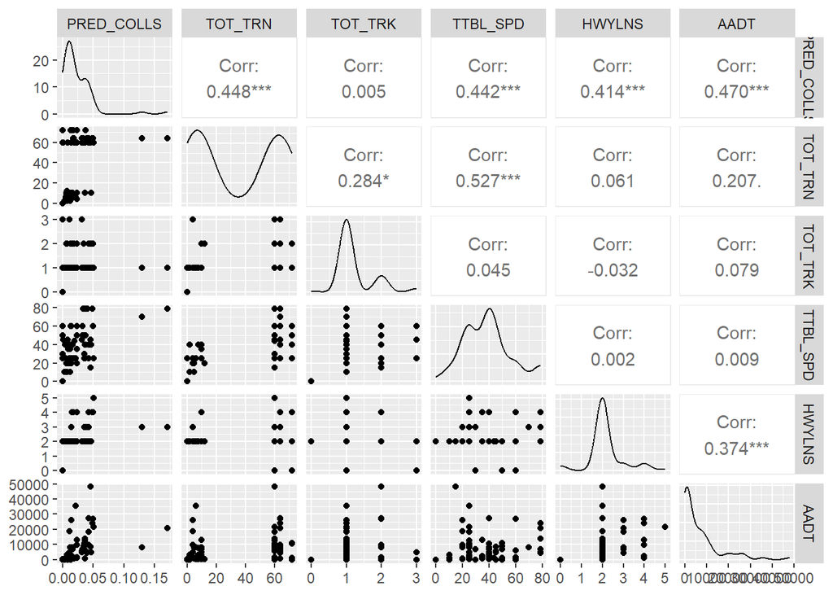

```r
chosen = c(2, 16:18, 20:21)
ggpairs(dataf[,chosen], progress=F)
```

We see there are a couple of outliers with very high `PRED_COLLS`.

```r
dataf[,chosen] %>% filter(PRED_COLLS>=.10)
```

```
## # A tibble: 2 × 6
##   PRED_COLLS TOT_TRN TOT_TRK TTBL_SPD HWYLNS  AADT
##        <dbl>   <dbl>   <dbl>    <dbl>  <dbl> <dbl>
## 1      0.171      64       1       79      3 20600
## 2      0.129      64       1       70      3  8100
```

```r
dataf[,chosen] %>% filter(PRED_COLLS<=.01)
```

```
## # A tibble: 25 × 6
##    PRED_COLLS TOT_TRN TOT_TRK TTBL_SPD HWYLNS  AADT
##         <dbl>   <dbl>   <dbl>    <dbl>  <dbl> <dbl>
##  1    0.00991      10       1       40      2  1000
##  2    0.00964      10       1       35      2   900
##  3    0.00934      10       1       40      2   800
##  4    0.00908       8       1       40      2   900
##  5    0.00849       8       1       40      2   700
##  6    0.00824      10       1       40      2   500
##  7    0.00815       8       1       40      2   600
##  8    0.00812      60       1       45      2   100
##  9    0.00776      12       2       20      2   300
## 10    0.00766       5       1       10      2  1104
## # ℹ 15 more rows
```

Very low `PRED_COLLS` go with low values of `AADT`,`TTBL_SPD`, and `TOT_TRN.`

# 5 Logistic regression analysis

A preliminary analysis was done using logistic regression; we used the `glm` routine in R. We tried a model for C using all the predictors.

```r
glm.fit1=glm(C~as.factor(WD)+TOT_TRN+TOT_TRK+TTBL_SPD+HWYLNS+AADT, data=dataf,family="binomial")
glm.fit1 %>% glance()
```

```
## # A tibble: 1 × 8
##   null.deviance df.null logLik   AIC   BIC deviance df.residual  nobs
##           <dbl>   <int>  <dbl> <dbl> <dbl>    <dbl>       <int> <int>
## 1          25.6      79  -9.06  42.1  70.7     18.1          68    80
```

```r
glm.fit1 %>% tidy %>% gt_add_significance()
```

| term | estimate | std.error | statistic | p.value |
| --- | --- | --- | --- | --- |
| (Intercept) | −17.2769 | 7,279.2429 | −0.0024 | 0.9981 |
| as.factor(WD)FQ | −3.5339 | 8,758.4122 | −0.0004 | 0.9997 |
| as.factor(WD)GT | 12.6775 | 7,279.2365 | 0.0017 | 0.9986 |
| as.factor(WD)HS | −2.4090 | 12,306.0119 | −0.0002 | 0.9998 |
| as.factor(WD)NO | −3.6173 | 14,497.2508 | −0.0002 | 0.9998 |
| as.factor(WD)SS | −0.2371 | 19,166.4623 | 0.0000 | 1.0000 |
| as.factor(WD)XB | −0.4972 | 19,166.4623 | 0.0000 | 1.0000 |
| TOT_TRN | −0.1433 | 0.1433 | −1.0002 | 0.3172 |
| TOT_TRK | −3.9823 | 11.1881 | −0.3559 | 0.7219 |
| TTBL_SPD | 0.2057 | 0.1780 | 1.1555 | 0.2479 |
| HWYLNS | −0.4243 | 1.2349 | −0.3436 | 0.7312 |
| AADT | 0.0001 | 0.0001 | 0.8817 | 0.3779 |

A smaller Akaike Information Criterion (AIC) would represent a better fit; one cannot use $R^2$, the conventional least squares regression measure of fit.

As a check we can use the caret package to assess the importance of the variables.

```r
library(caret); library(dplyr)
round(varImp(glm.fit1,scale=TRUE),4)
```

```
##                 Overall
## as.factor(WD)FQ  0.0004
## as.factor(WD)GT  0.0017
## as.factor(WD)HS  0.0002
## as.factor(WD)NO  0.0002
## as.factor(WD)SS  0.0000
## as.factor(WD)XB  0.0000
## TOT_TRN          1.0002
## TOT_TRK          0.3559
## TTBL_SPD         1.1555
## HWYLNS           0.3436
## AADT             0.8817
```

Clearly `TTBL_SPD` is most important; `TOT_TRN` is close behind; `AADT` is third; and `TOT_TRK` and `HWYLNS` are quite a bit less important.

# 6 Reduced form of logistic regression

It therefore makes sense to rerun the logistic regression, without the `WD` factors and `TOT_TRK`, `HWYLNS`, to see if a better result is obtained.

```r
glm.fit3=glm(C~TOT_TRN+TTBL_SPD+AADT, data=dataf, family="binomial")
glm.fit3 %>% glance
```

```
## # A tibble: 1 × 8
##   null.deviance df.null logLik   AIC   BIC deviance df.residual  nobs
##           <dbl>   <int>  <dbl> <dbl> <dbl>    <dbl>       <int> <int>
## 1          25.6      79  -9.46  26.9  36.5     18.9          76    80
```

```r
glm.fit3 %>% tidy %>% gt_add_significance()
```

| term | estimate | std.error | statistic | p.value |
| --- | --- | --- | --- | --- |
| (Intercept) | −10.3912 | 6.1513 | −1.6893 | 0.0912 |
| TOT_TRN | −0.1690 | 0.1464 | −1.1546 | 0.2482 |
| TTBL_SPD | 0.2316 | 0.1831 | 1.2649 | 0.2059 |
| AADT | 0.0001 | 0.0001 | 0.9104 | 0.3626 |

Now we see all predictor coefficients have relatively low p scores– below .37. The coefficients all go in the expected direction, if you consider that when there are lots of trains through a crossing each day, people tend to be more careful at the intersection.

# 7 Predicting probabilities of collision

We can use the results of the latter logistic regression to predict the probability of a collision at each crossing. Our results will be different from those of the WABS. We build a report to show the results for the crossings. The report will show city and road, type of equipment at the crossing, the predicted probability of collision, and the standard error of the prediction, which gives an idea of how confident we are in the prediction. it could be used to calculate confidence intervals on the predictions. We marked with a * the crossings at which the standard error was small enough so that Prediction was greater than SE, and hence one standard error below the Prediction was still positive probability of collision.

```
##           City                     Road Type Prediction  SEfit sig
## 5    SANTAROSA               PINER_ROAD   GT    0.30700 0.2876   *
## 16    PETALUMA              CORONA_ROAD   GT    0.26425 0.2190   *
## 1    SANTAROSA                HEARN_AVE   GT    0.24901 0.2239   *
## 71      FULTON            AVIATION_BLVD   GT    0.19704 0.2095
## 40      FULTON               RIVER_ROAD   GT    0.14239 0.1141   *
## 37      COTATI          EAST_COTATI_AVE   GT    0.10823 0.0774   *
## 38 ROHNERTPARK           SOUTHWEST_BLVD   GT    0.09945 0.0686   *
## 48     WINDSOR         WINDSOR_RIVER_RD   GT    0.09902 0.0721   *
## 53      FULTON              FULTON_ROAD   GT    0.09146 0.0675   *
## 22   SANTAROSA       BELLEVUE/CORBY_AVE   FQ    0.08986 0.1151
## 6  ROHNERTPARK        GOLF_COURSE_DRIVE   GT    0.08493 0.0571   *
## 59     WINDSOR               STARR_ROAD   GT    0.08308 0.0634   *
## 60      FULTON              SHILOH_ROAD   GT    0.08175 0.0628   *
## 62      FULTON             AIRPORT_BLVD   GT    0.08109 0.0626   *
```

[output cut: 66 more lines]

Let us select all the data with a Prediction (probability of collison) greater than 1 in 100 (0.01).

```r
d %>% filter(Prediction>.01)
```

```
##           City               Road Type Prediction  SEfit sig
## 5    SANTAROSA         PINER_ROAD   GT    0.30700 0.2876   *
## 16    PETALUMA        CORONA_ROAD   GT    0.26425 0.2190   *
## 1    SANTAROSA          HEARN_AVE   GT    0.24901 0.2239   *
## 71      FULTON      AVIATION_BLVD   GT    0.19704 0.2095
## 40      FULTON         RIVER_ROAD   GT    0.14239 0.1141   *
## 37      COTATI    EAST_COTATI_AVE   GT    0.10823 0.0774   *
## 38 ROHNERTPARK     SOUTHWEST_BLVD   GT    0.09945 0.0686   *
## 48     WINDSOR   WINDSOR_RIVER_RD   GT    0.09902 0.0721   *
## 53      FULTON        FULTON_ROAD   GT    0.09146 0.0675   *
## 22   SANTAROSA BELLEVUE/CORBY_AVE   FQ    0.08986 0.1151
## 6  ROHNERTPARK  GOLF_COURSE_DRIVE   GT    0.08493 0.0571   *
## 59     WINDSOR         STARR_ROAD   GT    0.08308 0.0634   *
## 60      FULTON        SHILOH_ROAD   GT    0.08175 0.0628   *
## 62      FULTON       AIRPORT_BLVD   GT    0.08109 0.0626   *
```

[output cut: 20 more lines]

The table shows 34 crossings have probabilities of a collision in the next year greater than 0.01 or 1 in 100.

If we look at the lowest ones, we will screen for the ones with a Prediction less than .0001, or one in ten thousand. We obtain 23 crossings with less than 1 in 10000.

```r
d %>% filter(Prediction < 0.0001)
```

```
##           City                     Road Type Prediction SEfit sig
## 8    SANRAFAEL          N_SANPEDRO_ROAD   GT      9e-05 5e-04
## 9    SANTAROSA         GUERNEVILLE_ROAD   GT      7e-05 5e-04
## 25    PETALUMA         LAKEVILLE_STREET   GT      7e-05 4e-04
## 14      NOVATO                GRANT_AVE   GT      4e-05 3e-04
## 32   SANRAFAEL           PACHECO_STREET   GT      4e-05 2e-04
## 63   SANRAFAEL                 PED_XING   FL      4e-05 3e-04
## 73   SANRAFAEL            PALOMA_AVENUE   GT      4e-05 3e-04
## 26   SANTAROSA               9TH_STREET   FQ      3e-05 2e-04
## 80 ROHNERTPARK                 PED_XING   GT      3e-05 2e-04
## 29      NOVATO          RUSHCREEK_PLACE   FQ      2e-05 1e-04
## 3     PETALUMA        WASHINGTON_STREET   GT      0e+00 0e+00
## 7    SANRAFAEL               4TH_STREET   FQ      0e+00 0e+00
## 10    PETALUMA            EAST_D_STREET   FQ      0e+00 0e+00
## 11   SANTAROSA               3RD_STREET   GT      0e+00 0e+00
## 15      NOVATO                OLIVE_AVE   GT      0e+00 0e+00
## 18   SANRAFAEL           MISSION_AVENUE   FQ      0e+00 0e+00
## 19   SANRAFAEL          CIVIC_CENTER_DR   GT      0e+00 0e+00
## 20   SANRAFAEL               5TH_AVENUE   FQ      0e+00 0e+00
## 33   SANTAROSA               8TH_STREET   GT      0e+00 0e+00
## 34   SANTAROSA               7TH_STREET   GT      0e+00 0e+00
## 35   SANTAROSA               6TH_STREET   GT      0e+00 0e+00
## 36    PETALUMA           CAULFIELD_LANE   GT      0e+00 0e+00
## 78   SANTAROSA Railroad_square_ped_xing   FL      0e+00 0e+00
```

# 8 Importance of variables

Which variable is most important? The package `caret` gives us a method for deciding. We see below that `TTBL_SPD` is a bit more important than `TOT_TRN`, and `AADT` is less important. But they are not greatly different in importance.

```r
library(caret)
caret::varImp(glm.fit3,scale=TRUE)
```

```
##            Overall
## TOT_TRN  1.1546445
## TTBL_SPD 1.2648867
## AADT     0.9104228
```

# 9 Residuals

Residual analysis is important as well, to see if we have a decent model for prediction. We call this candidate model **LOGR**.

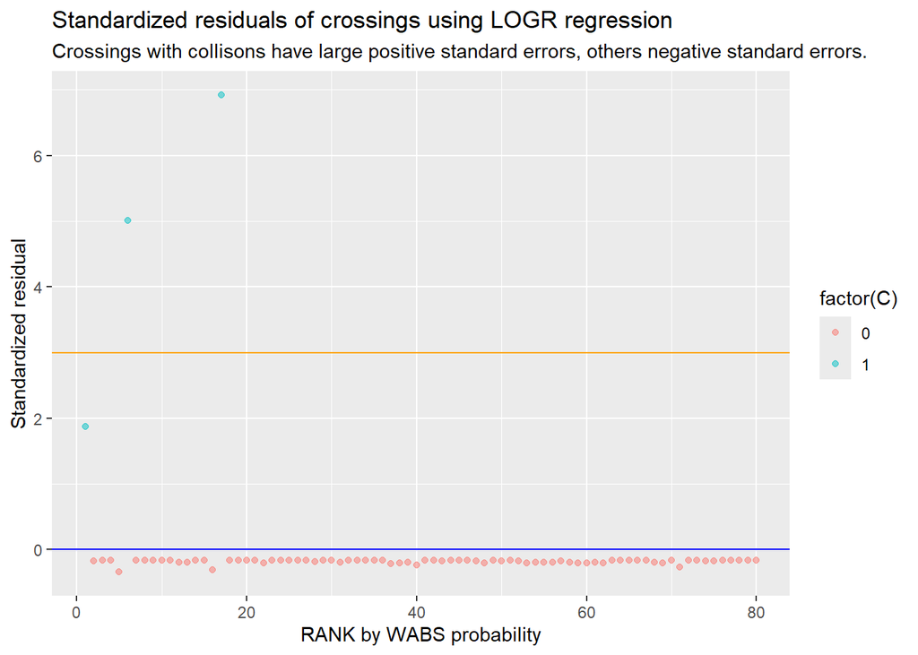

```r
glm.fit3_data = data.frame(
  RANK=dataf$RANK,
  name=paste0(dataf$CITY, "; ",
              substr(dataf$ROAD,1,20) ),
  std_resids = scale(glm.fit3$residuals),
  C = dataf$C,
  L=glm.fit3$fitted.values,
  W=dataf$PRED_COLLS )

ggplot(glm.fit3_data, aes( RANK, std_resids, color=factor(C) ) )  +
  geom_point(alpha = .5) +
  geom_hline(yintercept = 3, color = "orange") +
  geom_hline( yintercept=0, color = "blue") +
  labs( x = "RANK by WABS probability", y="Standardized residual",
        title= "Standardized residuals of crossings using LOGR regression",
        subtitle = "Crossings with collisons have large positive standard errors, others negative standard errors." )
```

As the above graph and table following show, only 3 crossings have residuals over 0, and these are the ones with collisions actually occurring. Which are these?

```r
glm.fit3_data %>% filter ( std_resids  > 0 )
```

```
##    RANK                           name std_resids C          L        W
## 1     1           SANTAROSA; HEARN_AVE   1.868924 1 0.24901172 0.171142
## 6     6 ROHNERTPARK; GOLF_COURSE_DRIVE   5.012333 1 0.08492718 0.046391
## 17   17           SANTAROSA; TODD_ROAD   6.916577 1 0.06069780 0.036735
```

# 10 Comparing with the WABS predictions

We will now compare our predictions from **LOGR** with the WABS predictions in the field `PRED_COLLS`. The easiest way to do this is via a graph, plotting the `PRED` against `PRED_COLLS`.

The graph shows that for the most part **LOGR** predicts a higher probability than WABS, particularly when the probability is over about .025, or 2.5%.

Let us then exclude all the ones with WABS predicted collision likelihood less than .02, and the two with WABS prediction above 0.1. This will show us the graph in a more detailed scale. Even in this smaller group it is clear that the **LOGR** method is obtaining a higher probability than the WABS predictions.

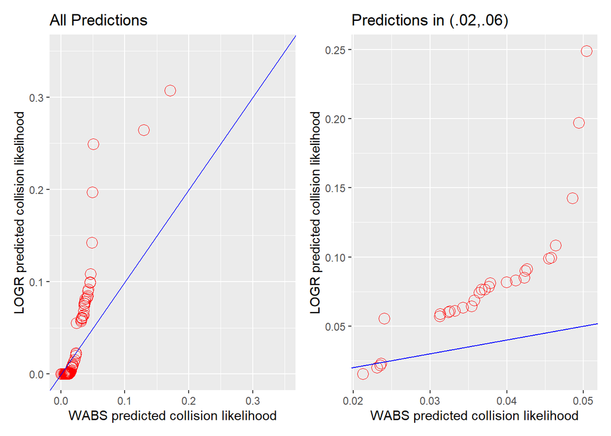

Comparisons of WABS and LOGR predictions

# 11 Predictions using interaction terms

Because of this upward bias in the **LOGR** predictions, we now revise the **LOGA** model to include only the interaction between `TTBL_SPD` and `AADT.` `AIC` is now negative, signifying a better fit. We first show a histogram of the distribution of prediction gap between **LOGA** and WABS. There are only 6 outliers with more absolute gap than 0.05.

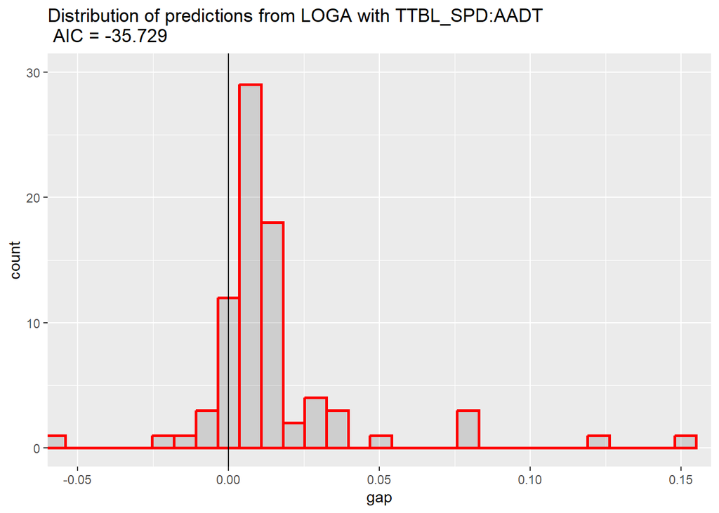

```r
glm.spdxaadt = glm(glm(C~TTBL_SPD:AADT, data=dataf, family="binomial"))  #+TTBL_SPD+AADT
s1=summary(glm.spdxaadt)
newdata = data.frame( HWYLNS= dataf$HWYLNS,TOT_TRN=dataf$TOT_TRN, TTBL_SPD=dataf$TTBL_SPD, AADT=dataf$AADT)
spdxaadt.pred=predict(glm.spdxaadt, newdata, type="response", se.fit=TRUE)
glm.spdxaadt_data = data.frame( RANK=dataf$RANK,
                                name=paste0(dataf$CITY,
                                            "; ",
                                            substr(dataf$ROAD,1,20) ),
                                std_resids = round(scale(glm.spdxaadt$residuals),4),
                                C = dataf$C,
                                L=round(glm.spdxaadt$fitted.values,4),
                                W=round(dataf$PRED_COLLS,4) ) %>%
  mutate ( gap=round(L-W, 4) )
ggplot(glm.spdxaadt_data, aes(gap)) +
  geom_histogram (color="red", alpha=0.2, size=1) +
  coord_cartesian( ylim= c(0,30), xlim=c(-0.05, 0.15)) +
  geom_vline ( xintercept = 0) +
  labs(title=paste0("Distribution of predictions from LOGA with TTBL_SPD:AADT \n AIC = ", round(s1$aic,3) ) )
```

We display the big 6 in descending order of the gap between **LOGA** and WABS (**LOGA** - WABS). Only one gap is negative.

```r
glm.spdxaadt_data %>% filter ( !between (gap, -.05,.05) ) %>%
  arrange ( desc(abs(gap) ) ) %>% gt
```

| RANK | name | std_resids | C | L | W | gap |
| --- | --- | --- | --- | --- | --- | --- |
| 5 | SANTAROSA; PINER_ROAD | -1.0467 | 0 | 0.1964 | 0.0485 | 0.1479 |
| 4 | SANTAROSA; COLLEGE_AVENUE | -0.9047 | 0 | 0.1697 | 0.0494 | 0.1203 |
| 16 | PETALUMA; CORONA_ROAD | -0.6337 | 0 | 0.1189 | 0.0371 | 0.0818 |
| 31 | SONOMA; SEARSPOINT/ST-37 | -0.5296 | 0 | 0.0994 | 0.0212 | 0.0782 |
| 9 | SANTAROSA; GUERNEVILLE_ROAD | -0.6343 | 0 | 0.1190 | 0.0426 | 0.0764 |
| 2 | SANTAROSA; STEELE_LANE | -0.3623 | 0 | 0.0680 | 0.1293 | -0.0613 |

# 12 Improving on **LOGA**

```r
glm.spdxaadttrn =
  glm(C~TOT_TRN + TTBL_SPD:AADT, data=dataf, family="binomial")  #+TTBL_SPD+AADT+TOT_TRN
s2 =summary(glm.spdxaadttrn)
newdata = data.frame(
  HWYLNS= dataf$HWYLNS,
  TOT_TRN=dataf$TOT_TRN,
  TTBL_SPD=dataf$TTBL_SPD,
  AADT=dataf$AADT)
spdxaadttrn.pred=predict(glm.spdxaadttrn, newdata, type="response", se.fit=TRUE)
glm.spdxaadttrn_data = data.frame(
  RANK=dataf$RANK,
  name=paste0(dataf$CITY,"; ", substr(dataf$ROAD,1,16) ),
  std_resids = round(scale(glm.spdxaadttrn$residuals),4),
  C = dataf$C,
  L=round(glm.spdxaadttrn$fitted.values,4),
  W=round(dataf$PRED_COLLS,4)
  ) %>%
  mutate ( gap=round(L-W, 4) )
glm.spdxaadttrn_data %>% filter ( !between (gap, -.05,.05) ) %>% arrange ( desc(abs(gap) ) )
```

```
##    RANK                      name std_resids C      L      W     gap
## 5     5     SANTAROSA; PINER_ROAD    -0.2562 0 0.2998 0.0485  0.2513
## 31   31  SONOMA; SEARSPOINT/ST-37    -0.2228 0 0.2146 0.0212  0.1934
## 4     4 SANTAROSA; COLLEGE_AVENUE    -0.2119 0 0.1824 0.0494  0.1330
## 2     2    SANTAROSA; STEELE_LANE    -0.1677 0 0.0182 0.1293 -0.1111
## 43   43     SANRAFAEL; 2ND_STREET    -0.1898 0 0.1076 0.0141  0.0935
## 52   52     SANRAFAEL; 3RD_STREET    -0.1823 0 0.0792 0.0115  0.0677
## 28   28  PETALUMA; NMCDOWELL_BLVD    -0.1821 0 0.0784 0.0236  0.0548
```

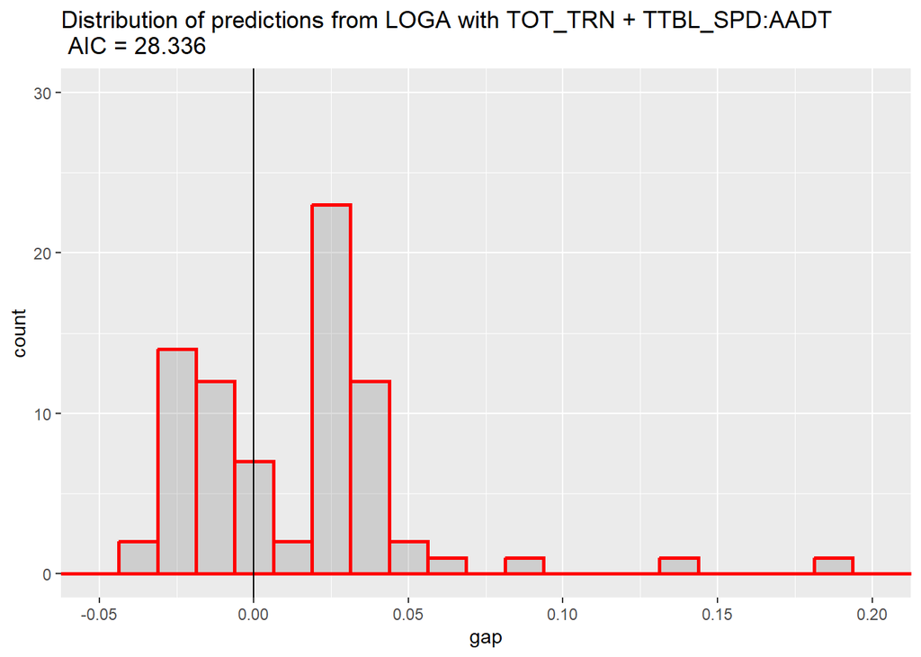

```r
ggplot(glm.spdxaadttrn_data, aes(gap)) +
  geom_histogram (color="red", alpha=0.2, size=1) +
  coord_cartesian( ylim= c(0,30), xlim=c(-0.05, 0.20)) +
  geom_vline ( xintercept = 0)+
  labs(title=paste0(
    "Distribution of predictions from LOGA with TOT_TRN + TTBL_SPD:AADT \n AIC = ",
    round(s2$aic,3) ) )
```